```python
!pip install folium plotly
```

```python
import pandas as pd
import numpy as np
import matplotlib.pyplot as plt
from collections import Counter
import folium
import plotly.graph_objects as go
import plotly

from bs4 import BeautifulSoup
import requests
from IPython.display import Image, display


mapbox_access_token = 'pk.eyJ1Ijoic3VubnkyMzA5IiwiYSI6ImNrMnlvNGRoMzA5YW0zY29tMGVhaWNwa2YifQ.E6iZyoNa1Inbf93yh-kjhw'

pd.set_option('display.max_columns',120)
pd.set_option('display.max_rows',100)

%matplotlib inline
```

# Exercise #1 - Data Cleaning

### Step 1.1 - Read in the data. Create a table of the unique values of Category. Which values do you believe represent a restaurant? Explain which categories you chose in a markdown cell. Create a single dummy variable for restaurant that combines multiple values from Category.

```python
food_inspection = pd.read_csv('Food_Inspection.csv')
#print('Columns : ',food_inspection.columns)
print('Food Inspection Dataframe Size : ',food_inspection.shape)
food_inspection.head()
```

```
Food Inspection Dataframe Size :  (32338, 30)
```

|  | Establishment_id | Name | Category | Inspection_date | Inspection_results | City | State | Zip | Address_line_1 | Address_line_2 | Food_from_approved_source | Food_protected_from_contamination | Ill_workers_restricted | Proper_hand_washing | Cooling_time_and_temperature | Cold_holding_temperature | Hot_holding_temperature | Cooking_time_and_temperature | Reheating_time_and_temperature | Hot_and_cold_running_water_provided | Proper_sewage_disposal | No_bare_hand_contact | Adequate_hand_washing_facilities | Rodent_and_insects | Food_contact_surfaces_and_equipment | Inspection_type | Owner | Type | Location | … |
| --- | --- | --- | --- | --- | --- | --- | --- | --- | --- | --- | --- | --- | --- | --- | --- | --- | --- | --- | --- | --- | --- | --- | --- | --- | --- | --- | --- | --- | --- | --- |
| 0 | 8176 | LAUREL DUTCH MARKET - SAMMIE'S PRODUCE | Carry-out | 09/05/2019 12:00:00 AM | Critical Violations observed | LAUREL | MD | 20707.0 | 9701 FORT MEADE RD | ------ | In Compliance | Out of Compliance | In Compliance | In Compliance | In Compliance | In Compliance | In Compliance | In Compliance | In Compliance | In Compliance | In Compliance | In Compliance | In Compliance | In Compliance | In Compliance | Monitoring | Samuel Stoltzfus | Food Establishments | POINT (-76.838165 39.095491) | … |
| 1 | 14622 | JERSEY MIKE'S SUBS | Fast Food | 09/06/2019 12:00:00 AM | Critical Violations observed | Riverdale | MD | 20737.0 | 6761 45th ST | ------ | In Compliance | In Compliance | In Compliance | In Compliance | In Compliance | Out of Compliance | In Compliance | In Compliance | In Compliance | In Compliance | In Compliance | In Compliance | In Compliance | In Compliance | In Compliance | Re-inspection | DANIEL MALAMIS | Food Establishments | NaN | … |
| 2 | 7273 | ACCOKEEK ACADEMY | Public School | 09/09/2019 12:00:00 AM | Non-Compliant - Violations Observed | ACCOKEEK | MD | 20607.0 | 14400 BERRY RD | ------ | In Compliance | In Compliance | In Compliance | In Compliance | In Compliance | In Compliance | In Compliance | In Compliance | In Compliance | In Compliance | In Compliance | In Compliance | In Compliance | In Compliance | In Compliance | Comprehensive | MARK FOSSETT | Food Establishments | POINT (-76.980676 38.687531) | … |
| 3 | 2103 | PAPA JOHNS 728 | Carry-out | 09/05/2019 12:00:00 AM | Compliant - No Health Risk | BOWIE | MD | 20715.0 | 6852 RACE TRACK RD | ------ | In Compliance | In Compliance | In Compliance | In Compliance | In Compliance | In Compliance | In Compliance | In Compliance | In Compliance | In Compliance | In Compliance | In Compliance | In Compliance | In Compliance | In Compliance | Re-inspection | Annie Berkovicz | Food Establishments | POINT (-76.729269 38.983881) | … |
| 4 | 347 | COLUMBIA PARK ELEMENTARY SCHOOL | Public School | 09/05/2019 12:00:00 AM | Critical Violations observed | LANDOVER | MD | 20785.0 | 1901 KENT VILLAGE DR | ------ | In Compliance | In Compliance | In Compliance | In Compliance | In Compliance | Out of Compliance | In Compliance | In Compliance | In Compliance | In Compliance | In Compliance | In Compliance | In Compliance | Out of Compliance | In Compliance | Comprehensive | MARK FOSSETT | Food Establishments | POINT (-76.88767 38.91584) | … |

```python
food_inspection[['Category']].drop_duplicates()
```

|  | Category |
| --- | --- |
| 0 | Carry-out |
| 1 | Fast Food |
| 2 | Public School |
| 7 | Hotel |
| 12 | NaN |
| 13 | Grocery Store |
| 14 | Convenience Store |
| 16 | Full Service |
| 18 | Ice Cream |
| 34 | Bakery/Catering |
| 36 | Gas Station Store |
| 41 | College/University |
| 43 | Restaurant |
| 53 | Health Care Facility |
| 56 | Bar/Tavern/Lounge |
| 58 | Dollar Store |
| 62 | Bakery |
| 74 | Private School |
| 85 | Coffee Shop |
| 159 | Stadium/Amusement Park |
| 165 | Limited Service |
| 169 | Casino |
| 170 | Church/Temple/Mosque |
| 200 | Catering Only |
| 245 | Cafeteria |
| 257 | Group Home |
| 381 | Meat/Poultry Market |
| 540 | Snack Bar/Concession Stand |
| 656 | Multiple Facilities |
| 693 | Pre-Packaged Only |
| 749 | Deli |
| 806 | Private Club |
| 940 | Fire/Community Hall |
| 952 | Banquet Hall/Ballroom |
| 963 | Seafood |
| 1003 | Institution |
| 1097 | After School Supper Program |
| 1146 | Night Club |
| 1307 | Membership Warehouse |
| 1419 | Full Service/Catering |
| 1853 | Buffet |
| 2451 | Diner |
| 13400 | Senior Nutrition Program |
| 13424 | Pizza |
| 14261 | Donut |
| 25397 | Excluded |
| 26059 | Farmer's Market |
| 26110 | Micro Market |
| 28391 | B & B |
| 31897 | School |

```python
list_of_restaurants = ['Fast Food', 'Restaurant', 'Cafeteria', 'Seafood', 'Buffet', 'Diner','Pizza']
#list_of_restaurants = ['Restaurant']
food_inspection['Restaurant'] = [True if val in list_of_restaurants else False for val in food_inspection['Category'].values]
```

```python
food_inspection[food_inspection.Restaurant == True]['Establishment_id'].value_counts()
```

```
1321     53
1756     30
822      29
1644     28
1757     28
         ..
2587      1
8300      1
14801     1
14558     1
8047      1
Name: Establishment_id, Length: 522, dtype: int64
```

```python
food_inspection.head()
```

|  | Establishment_id | Name | Category | Inspection_date | Inspection_results | City | State | Zip | Address_line_1 | Address_line_2 | Food_from_approved_source | Food_protected_from_contamination | Ill_workers_restricted | Proper_hand_washing | Cooling_time_and_temperature | Cold_holding_temperature | Hot_holding_temperature | Cooking_time_and_temperature | Reheating_time_and_temperature | Hot_and_cold_running_water_provided | Proper_sewage_disposal | No_bare_hand_contact | Adequate_hand_washing_facilities | Rodent_and_insects | Food_contact_surfaces_and_equipment | Inspection_type | Owner | Type | Location | … |
| --- | --- | --- | --- | --- | --- | --- | --- | --- | --- | --- | --- | --- | --- | --- | --- | --- | --- | --- | --- | --- | --- | --- | --- | --- | --- | --- | --- | --- | --- | --- |
| 0 | 8176 | LAUREL DUTCH MARKET - SAMMIE'S PRODUCE | Carry-out | 09/05/2019 12:00:00 AM | Critical Violations observed | LAUREL | MD | 20707.0 | 9701 FORT MEADE RD | ------ | In Compliance | Out of Compliance | In Compliance | In Compliance | In Compliance | In Compliance | In Compliance | In Compliance | In Compliance | In Compliance | In Compliance | In Compliance | In Compliance | In Compliance | In Compliance | Monitoring | Samuel Stoltzfus | Food Establishments | POINT (-76.838165 39.095491) | … |
| 1 | 14622 | JERSEY MIKE'S SUBS | Fast Food | 09/06/2019 12:00:00 AM | Critical Violations observed | Riverdale | MD | 20737.0 | 6761 45th ST | ------ | In Compliance | In Compliance | In Compliance | In Compliance | In Compliance | Out of Compliance | In Compliance | In Compliance | In Compliance | In Compliance | In Compliance | In Compliance | In Compliance | In Compliance | In Compliance | Re-inspection | DANIEL MALAMIS | Food Establishments | NaN | … |
| 2 | 7273 | ACCOKEEK ACADEMY | Public School | 09/09/2019 12:00:00 AM | Non-Compliant - Violations Observed | ACCOKEEK | MD | 20607.0 | 14400 BERRY RD | ------ | In Compliance | In Compliance | In Compliance | In Compliance | In Compliance | In Compliance | In Compliance | In Compliance | In Compliance | In Compliance | In Compliance | In Compliance | In Compliance | In Compliance | In Compliance | Comprehensive | MARK FOSSETT | Food Establishments | POINT (-76.980676 38.687531) | … |
| 3 | 2103 | PAPA JOHNS 728 | Carry-out | 09/05/2019 12:00:00 AM | Compliant - No Health Risk | BOWIE | MD | 20715.0 | 6852 RACE TRACK RD | ------ | In Compliance | In Compliance | In Compliance | In Compliance | In Compliance | In Compliance | In Compliance | In Compliance | In Compliance | In Compliance | In Compliance | In Compliance | In Compliance | In Compliance | In Compliance | Re-inspection | Annie Berkovicz | Food Establishments | POINT (-76.729269 38.983881) | … |
| 4 | 347 | COLUMBIA PARK ELEMENTARY SCHOOL | Public School | 09/05/2019 12:00:00 AM | Critical Violations observed | LANDOVER | MD | 20785.0 | 1901 KENT VILLAGE DR | ------ | In Compliance | In Compliance | In Compliance | In Compliance | In Compliance | Out of Compliance | In Compliance | In Compliance | In Compliance | In Compliance | In Compliance | In Compliance | In Compliance | Out of Compliance | In Compliance | Comprehensive | MARK FOSSETT | Food Establishments | POINT (-76.88767 38.91584) | … |

### Step 1.2 - Convert the Inspection_date column into a datetime column. Create a new column for the year of the inspection. Create a new column for the month of the inspection. Create a column for the year and month.

```python
print('Food Inspection Date Datatype Before', food_inspection['Inspection_date'].dtype)
food_inspection['Inspection_date'] = pd.to_datetime(food_inspection['Inspection_date'])
print('Food Inspection Date Datatype Before', food_inspection['Inspection_date'].dtype)

food_inspection['Inspection_year'] = [dt.year for dt in food_inspection['Inspection_date']]
food_inspection['Inspection_month'] = [dt.month for dt in food_inspection['Inspection_date']]
food_inspection['Inspection_year_month'] = food_inspection['Inspection_month'].map(str) + '_' + food_inspection['Inspection_year'].map(str)
```

```
Food Inspection Date Datatype Before object
Food Inspection Date Datatype Before datetime64[ns]
```

```python
food_inspection[['Inspection_date', 'Inspection_year', 'Inspection_month', 'Inspection_year_month']]
```

|  | Inspection_date | Inspection_year | Inspection_month | Inspection_year_month |
| --- | --- | --- | --- | --- |
| 0 | 2019-09-05 | 2019 | 9 | 9_2019 |
| 1 | 2019-09-06 | 2019 | 9 | 9_2019 |
| 2 | 2019-09-09 | 2019 | 9 | 9_2019 |
| 3 | 2019-09-05 | 2019 | 9 | 9_2019 |
| 4 | 2019-09-05 | 2019 | 9 | 9_2019 |
| ... | ... | ... | ... | ... |
| 32333 | 2019-08-29 | 2019 | 8 | 8_2019 |
| 32334 | 2019-08-29 | 2019 | 8 | 8_2019 |
| 32335 | 2019-08-26 | 2019 | 8 | 8_2019 |
| 32336 | 2019-08-24 | 2019 | 8 | 8_2019 |
| 32337 | 2019-08-28 | 2019 | 8 | 8_2019 |

32338 rows × 4 columns

### Step 1.3 - For each column with the type of compliance, e.g. "Rodent and Insects," create a dummy variable that is 1 if the establishment is out of compliance and 0 otherwise. Use np.nan for not applicable. Drop the string columns (retain only the dummy variables).

```python
compliance_type_columns = ['Food_from_approved_source', 'Food_protected_from_contamination', 'Ill_workers_restricted', \
                           'Proper_hand_washing', 'Cooling_time_and_temperature', 'Cold_holding_temperature',\
                          'Hot_holding_temperature', 'Cooking_time_and_temperature', 'Reheating_time_and_temperature',\
                          'Hot_and_cold_running_water_provided', 'Proper_sewage_disposal', 'No_bare_hand_contact', \
                          'Adequate_hand_washing_facilities', 'Rodent_and_insects', 'Food_contact_surfaces_and_equipment']
for col in compliance_type_columns:
    print(col,' : ',food_inspection[col].unique())

for col in compliance_type_columns:
    food_inspection[col] = [(1 if val=='Out of Compliance' else 0 if val=='In Compliance' else np.nan ) for val in food_inspection[col]]
```

```
Food_from_approved_source  :  ['In Compliance' 'Out of Compliance']
Food_protected_from_contamination  :  ['Out of Compliance' 'In Compliance']
Ill_workers_restricted  :  ['In Compliance' 'Out of Compliance']
Proper_hand_washing  :  ['In Compliance' 'Out of Compliance']
Cooling_time_and_temperature  :  ['In Compliance' 'Out of Compliance']
Cold_holding_temperature  :  ['In Compliance' 'Out of Compliance']
Hot_holding_temperature  :  ['In Compliance' 'Out of Compliance']
Cooking_time_and_temperature  :  ['In Compliance' 'Out of Compliance']
Reheating_time_and_temperature  :  ['In Compliance' 'Out of Compliance']
Hot_and_cold_running_water_provided  :  ['In Compliance' 'Out of Compliance']
Proper_sewage_disposal  :  ['In Compliance' 'Out of Compliance']
No_bare_hand_contact  :  ['In Compliance']
Adequate_hand_washing_facilities  :  ['In Compliance']
Rodent_and_insects  :  ['In Compliance' 'Out of Compliance']
Food_contact_surfaces_and_equipment  :  ['In Compliance' 'Out of Compliance']
```

```python
food_inspection[compliance_type_columns]
```

|  | Food_from_approved_source | Food_protected_from_contamination | Ill_workers_restricted | Proper_hand_washing | Cooling_time_and_temperature | Cold_holding_temperature | Hot_holding_temperature | Cooking_time_and_temperature | Reheating_time_and_temperature | Hot_and_cold_running_water_provided | Proper_sewage_disposal | No_bare_hand_contact | Adequate_hand_washing_facilities | Rodent_and_insects | Food_contact_surfaces_and_equipment |
| --- | --- | --- | --- | --- | --- | --- | --- | --- | --- | --- | --- | --- | --- | --- | --- |
| 0 | 0 | 1 | 0 | 0 | 0 | 0 | 0 | 0 | 0 | 0 | 0 | 0 | 0 | 0 | 0 |
| 1 | 0 | 0 | 0 | 0 | 0 | 1 | 0 | 0 | 0 | 0 | 0 | 0 | 0 | 0 | 0 |
| 2 | 0 | 0 | 0 | 0 | 0 | 0 | 0 | 0 | 0 | 0 | 0 | 0 | 0 | 0 | 0 |
| 3 | 0 | 0 | 0 | 0 | 0 | 0 | 0 | 0 | 0 | 0 | 0 | 0 | 0 | 0 | 0 |
| 4 | 0 | 0 | 0 | 0 | 0 | 1 | 0 | 0 | 0 | 0 | 0 | 0 | 0 | 1 | 0 |
| ... | ... | ... | ... | ... | ... | ... | ... | ... | ... | ... | ... | ... | ... | ... | ... |
| 32333 | 0 | 0 | 0 | 0 | 0 | 0 | 1 | 0 | 0 | 0 | 0 | 0 | 0 | 0 | 1 |
| 32334 | 0 | 0 | 0 | 0 | 0 | 0 | 0 | 0 | 0 | 0 | 0 | 0 | 0 | 0 | 0 |
| 32335 | 0 | 0 | 0 | 0 | 0 | 0 | 0 | 0 | 0 | 0 | 0 | 0 | 0 | 0 | 0 |
| 32336 | 0 | 0 | 0 | 0 | 0 | 0 | 0 | 0 | 0 | 0 | 0 | 0 | 0 | 0 | 0 |
| 32337 | 0 | 0 | 0 | 0 | 0 | 0 | 0 | 0 | 0 | 0 | 0 | 0 | 0 | 0 | 0 |

32338 rows × 15 columns

### Step 1.4 - Create a new column that contains the number of violations for that inspection (the number of categories where the establishment was not in compliance). Create a dummy variable that is 1 if the establishment is out of compliance in any category.

```python
food_inspection['Num_of_violations'] = [val.sum() for val in food_inspection[compliance_type_columns].values]
food_inspection['Num_of_violations']
```

```
0        1
1        1
2        0
3        0
4        2
        ..
32333    2
32334    0
32335    0
32336    0
32337    0
Name: Num_of_violations, Length: 32338, dtype: int64
```

```python
food_inspection['Out_of_compliance'] = [1 if val>0 else 0 for val in food_inspection['Num_of_violations']]
food_inspection['Out_of_compliance']
```

```
0        1
1        1
2        0
3        0
4        1
        ..
32333    1
32334    0
32335    0
32336    0
32337    0
Name: Out_of_compliance, Length: 32338, dtype: int64
```

### Step 1.5 - For establishments with multiple inspections, create a new DataFrame in wide format. Keep only the establishment ID, Category, Inspection_date, and number of violations. Make sure category is consistent within ID and resolve any discrepancies if necessary (i.e. each establishment has only one category). Reshape from long to wide (pivot) such that each establishment is a row and you have a column for the date and number of violations for inspection 1, inspection 2, inspection 3, etc.

```python
establishment_id_to_inspection_cnt = Counter(food_inspection[food_inspection.Restaurant == True].Establishment_id)
establishment_id_to_inspection_cnt = dict([(key,val) for key, val in establishment_id_to_inspection_cnt.items() if val > 1])

food_inspection_multi_insp = food_inspection[food_inspection.Establishment_id.isin(establishment_id_to_inspection_cnt.keys())].copy()
sub_food_inspection = food_inspection_multi_insp[['Establishment_id', 'Category', 'Inspection_date', 'Num_of_violations']]
sub_food_inspection.head()
```

|  | Establishment_id | Category | Inspection_date | Num_of_violations |
| --- | --- | --- | --- | --- |
| 1 | 14622 | Fast Food | 2019-09-06 | 1 |
| 6 | 1453 | Fast Food | 2019-09-09 | 1 |
| 8 | 804 | Fast Food | 2019-09-12 | 0 |
| 30 | 36 | Fast Food | 2019-08-15 | 0 |
| 40 | 8153 | Fast Food | 2019-09-05 | 1 |

```python
total_data = []
for idx, df in sub_food_inspection.groupby('Establishment_id'):
    row_data = [df['Establishment_id'].values[0],df['Category'].values[0]]
    dates_violations = list(zip(df['Inspection_date'],df['Num_of_violations']))
    for d_v in dates_violations:
        row_data.extend(d_v)
    total_data.append(row_data)
```

```python
max_cnt = max([len(row) for row in total_data])
print(max_cnt)

columns = ['Establishment_id', 'Category']
for i in range((max_cnt-2)//2):
    columns.extend(['Inspection_date_%d'%(i+1),'Inspection_%d'%(i+1)])

est_to_datewise_insp_viols = pd.DataFrame(total_data, columns=columns)
est_to_datewise_insp_viols.head(10)
```

```
108
```

|  | Establishment_id | Category | Inspection_date_1 | Inspection_1 | Inspection_date_2 | Inspection_2 | Inspection_date_3 | Inspection_3 | Inspection_date_4 | Inspection_4 | Inspection_date_5 | Inspection_5 | Inspection_date_6 | Inspection_6 | Inspection_date_7 | Inspection_7 | Inspection_date_8 | Inspection_8 | Inspection_date_9 | Inspection_9 | Inspection_date_10 | Inspection_10 | Inspection_date_11 | Inspection_11 | Inspection_date_12 | Inspection_12 | Inspection_date_13 | Inspection_13 | Inspection_date_14 | … |
| --- | --- | --- | --- | --- | --- | --- | --- | --- | --- | --- | --- | --- | --- | --- | --- | --- | --- | --- | --- | --- | --- | --- | --- | --- | --- | --- | --- | --- | --- | --- |
| 0 | 8 | Restaurant | 2017-05-05 | 1 | 2016-04-04 | 3 | 2014-09-29 | 3.0 | 2015-09-15 | 0.0 | 2016-12-08 | 3.0 | 2019-03-12 | 0.0 | 2012-08-06 | 0.0 | 2012-12-12 | 0.0 | 2013-06-12 | 2.0 | NaT | NaN | NaT | NaN | NaT | NaN | NaT | NaN | NaT | … |
| 1 | 18 | Fast Food | 2019-10-30 | 1 | 2015-07-28 | 1 | 2012-02-24 | 0.0 | 2014-10-10 | 0.0 | 2017-06-20 | 2.0 | 2019-03-11 | 1.0 | 2016-01-06 | 0.0 | 2012-09-12 | 0.0 | 2014-08-13 | 0.0 | 2014-11-21 | 0.0 | 2018-03-26 | 0.0 | 2011-11-23 | 0.0 | 2015-01-13 | 0.0 | 2013-04-17 | … |
| 2 | 22 | Fast Food | 2019-10-21 | 0 | 2018-07-09 | 0 | 2016-04-14 | 1.0 | 2015-11-25 | 2.0 | 2013-09-05 | 0.0 | 2015-02-09 | 0.0 | 2014-04-18 | 1.0 | 2018-07-06 | 1.0 | 2019-02-11 | 0.0 | 2019-01-31 | 0.0 | 2018-08-22 | 2.0 | 2014-09-23 | 1.0 | 2017-06-26 | 0.0 | 2017-04-21 | … |
| 3 | 35 | Fast Food | 2019-08-30 | 0 | 2019-08-30 | 0 | 2015-01-12 | 0.0 | 2017-04-03 | 3.0 | 2013-03-18 | 0.0 | 2015-06-25 | 1.0 | 2016-09-29 | 0.0 | 2014-09-22 | 0.0 | 2016-02-02 | 0.0 | 2018-02-14 | 1.0 | 2014-08-25 | 0.0 | 2017-06-14 | 1.0 | 2018-09-12 | 0.0 | 2016-10-04 | … |
| 4 | 36 | Fast Food | 2019-08-15 | 0 | 2019-07-17 | 0 | 2019-07-17 | 0.0 | 2019-08-15 | 0.0 | 2019-08-26 | 0.0 | 2019-07-17 | 0.0 | 2019-08-15 | 0.0 | 2019-08-26 | 0.0 | 2013-06-11 | 3.0 | 2017-04-27 | 0.0 | 2016-11-30 | 0.0 | 2012-08-13 | 2.0 | 2015-05-28 | 3.0 | 2017-04-12 | … |
| 5 | 37 | Fast Food | 2017-01-06 | 0 | 2018-04-02 | 0 | 2015-09-28 | 0.0 | 2017-06-12 | 0.0 | 2015-09-28 | 0.0 | 2013-04-01 | 2.0 | 2019-07-29 | 1.0 | 2018-10-16 | 0.0 | 2018-06-07 | 0.0 | 2015-02-06 | 0.0 | 2017-11-08 | 2.0 | 2018-07-30 | 2.0 | 2015-02-06 | 0.0 | 2017-12-15 | … |
| 6 | 38 | Fast Food | 2015-08-25 | 1 | 2016-03-10 | 1 | 2019-02-11 | 4.0 | 2018-08-13 | 2.0 | 2014-04-29 | 1.0 | 2012-12-24 | 1.0 | 2015-12-11 | 0.0 | 2016-03-10 | 0.0 | 2015-01-28 | 0.0 | 2013-06-03 | 0.0 | 2019-06-18 | 3.0 | 2016-12-05 | 0.0 | 2018-01-16 | 2.0 | 2019-02-25 | … |
| 7 | 39 | Fast Food | 2015-10-20 | 0 | 2017-06-09 | 1 | 2014-10-14 | 0.0 | 2016-06-22 | 2.0 | 2019-04-26 | 0.0 | 2014-12-29 | 0.0 | 2019-04-26 | 2.0 | 2013-08-23 | 0.0 | 2015-07-22 | 0.0 | 2017-02-17 | 1.0 | 2019-05-03 | 0.0 | 2015-07-22 | 0.0 | 2014-11-25 | 0.0 | 2014-08-05 | … |
| 8 | 40 | Fast Food | 2017-10-26 | 2 | 2017-01-26 | 3 | 2015-04-06 | 0.0 | 2013-11-18 | 0.0 | 2016-05-16 | 3.0 | 2014-06-12 | 3.0 | 2015-02-09 | 2.0 | 2015-10-05 | 3.0 | 2017-03-06 | 0.0 | NaT | NaN | NaT | NaN | NaT | NaN | NaT | NaN | NaT | … |
| 9 | 43 | Restaurant | 2019-10-28 | 2 | 2016-04-06 | 2 | 2018-05-07 | 0.0 | 2011-07-13 | 2.0 | 2015-02-18 | 3.0 | 2017-12-08 | 3.0 | 2015-04-01 | 1.0 | NaT | NaN | NaT | NaN | NaT | NaN | NaT | NaN | NaT | NaN | NaT | NaN | NaT | … |

# Exercise #2 - Summary Statistics/Grouped Data

### Step 2.1 - What is the most common type of violation? The compliance categories are not mutually exclusive because one restaurant can have multiple violations. Create a table with the number of violations by violation type. Sort the table from the most common to least common violations.

```python
violation_type_to_cnt = pd.DataFrame(food_inspection[food_inspection.Restaurant == True][compliance_type_columns].sum().sort_values(ascending=False)).rename(columns={0:'Num_of_violations'})
violation_type_to_cnt
```

|  | Num_of_violations |
| --- | --- |
| Cold_holding_temperature | 1262 |
| Food_contact_surfaces_and_equipment | 1236 |
| Rodent_and_insects | 901 |
| Hot_holding_temperature | 586 |
| Proper_hand_washing | 240 |
| Food_protected_from_contamination | 186 |
| Cooling_time_and_temperature | 57 |
| Hot_and_cold_running_water_provided | 38 |
| Cooking_time_and_temperature | 29 |
| Reheating_time_and_temperature | 27 |
| Proper_sewage_disposal | 16 |
| Food_from_approved_source | 8 |
| Ill_workers_restricted | 5 |
| Adequate_hand_washing_facilities | 0 |
| No_bare_hand_contact | 0 |

**Findings:** From above we can see that **Cold_holding_temperature** is most common type of violation.

### Step 2.2 - For establishments with multiple inspections, how many reinspections does it take for an establishment to become compliant? Create a table where each row is the number of inspections a restaurant has had and the columns are the number of reinspections until the establishment becomes compliant. Write 2-4 sentences with your observations. A mock up of this table is below (you will have more rows)

```python
all_data = []
for i in range(2, (max_cnt-2)//2):
    sub_df = est_to_datewise_insp_viols[est_to_datewise_insp_viols['Inspection_%d'%i] == 0]
    row_data = [sub_df['Inspection_1'].sum(),]
    for j in range(2, i+1):
        row_data.append(sub_df['Inspection_%d'%j].sum())
    all_data.append(row_data)

max_cnt = max([len(row) for row in all_data])
index = ['%d Inspections'%(i+1) for i in range(len(all_data))]
columns = ['Never Compliant']
columns.extend(['Compliant After %d Re-Inspections'%(i+1) for i in range(max_cnt-1)])

no_violations_to_become_compliant = pd.DataFrame(all_data, columns = columns, index=index)
```

```python
no_violations_to_become_compliant.loc['Total'] = no_violations_to_become_compliant[1:].sum()
no_violations_to_become_compliant['Total'] = no_violations_to_become_compliant.sum(axis=1)
no_violations_to_become_compliant[1:]
```

|  | Never Compliant | Compliant After 1 Re-Inspections | Compliant After 2 Re-Inspections | Compliant After 3 Re-Inspections | Compliant After 4 Re-Inspections | Compliant After 5 Re-Inspections | Compliant After 6 Re-Inspections | Compliant After 7 Re-Inspections | Compliant After 8 Re-Inspections | Compliant After 9 Re-Inspections | Compliant After 10 Re-Inspections | Compliant After 11 Re-Inspections | Compliant After 12 Re-Inspections | Compliant After 13 Re-Inspections | Compliant After 14 Re-Inspections | Compliant After 15 Re-Inspections | Compliant After 16 Re-Inspections | Compliant After 17 Re-Inspections | Compliant After 18 Re-Inspections | Compliant After 19 Re-Inspections | Compliant After 20 Re-Inspections | Compliant After 21 Re-Inspections | Compliant After 22 Re-Inspections | Compliant After 23 Re-Inspections | Compliant After 24 Re-Inspections | Compliant After 25 Re-Inspections | Compliant After 26 Re-Inspections | Compliant After 27 Re-Inspections | Compliant After 28 Re-Inspections | … |
| --- | --- | --- | --- | --- | --- | --- | --- | --- | --- | --- | --- | --- | --- | --- | --- | --- | --- | --- | --- | --- | --- | --- | --- | --- | --- | --- | --- | --- | --- | --- |
| 2 Inspections | 187.0 | 190.0 | 0.0 | NaN | NaN | NaN | NaN | NaN | NaN | NaN | NaN | NaN | NaN | NaN | NaN | NaN | NaN | NaN | NaN | NaN | NaN | NaN | NaN | NaN | NaN | NaN | NaN | NaN | NaN | … |
| 3 Inspections | 196.0 | 186.0 | 184.0 | 0.0 | NaN | NaN | NaN | NaN | NaN | NaN | NaN | NaN | NaN | NaN | NaN | NaN | NaN | NaN | NaN | NaN | NaN | NaN | NaN | NaN | NaN | NaN | NaN | NaN | NaN | … |
| 4 Inspections | 180.0 | 178.0 | 155.0 | 170.0 | 0.0 | NaN | NaN | NaN | NaN | NaN | NaN | NaN | NaN | NaN | NaN | NaN | NaN | NaN | NaN | NaN | NaN | NaN | NaN | NaN | NaN | NaN | NaN | NaN | NaN | … |
| 5 Inspections | 153.0 | 151.0 | 164.0 | 140.0 | 167.0 | 0.0 | NaN | NaN | NaN | NaN | NaN | NaN | NaN | NaN | NaN | NaN | NaN | NaN | NaN | NaN | NaN | NaN | NaN | NaN | NaN | NaN | NaN | NaN | NaN | … |
| 6 Inspections | 172.0 | 158.0 | 154.0 | 157.0 | 159.0 | 151.0 | 0.0 | NaN | NaN | NaN | NaN | NaN | NaN | NaN | NaN | NaN | NaN | NaN | NaN | NaN | NaN | NaN | NaN | NaN | NaN | NaN | NaN | NaN | NaN | … |
| 7 Inspections | 168.0 | 162.0 | 177.0 | 160.0 | 161.0 | 166.0 | 162.0 | 0.0 | NaN | NaN | NaN | NaN | NaN | NaN | NaN | NaN | NaN | NaN | NaN | NaN | NaN | NaN | NaN | NaN | NaN | NaN | NaN | NaN | NaN | … |
| 8 Inspections | 152.0 | 144.0 | 135.0 | 145.0 | 132.0 | 158.0 | 167.0 | 144.0 | 0.0 | NaN | NaN | NaN | NaN | NaN | NaN | NaN | NaN | NaN | NaN | NaN | NaN | NaN | NaN | NaN | NaN | NaN | NaN | NaN | NaN | … |
| 9 Inspections | 147.0 | 154.0 | 137.0 | 141.0 | 140.0 | 127.0 | 140.0 | 134.0 | 138.0 | 0.0 | NaN | NaN | NaN | NaN | NaN | NaN | NaN | NaN | NaN | NaN | NaN | NaN | NaN | NaN | NaN | NaN | NaN | NaN | NaN | … |
| 10 Inspections | 148.0 | 141.0 | 135.0 | 109.0 | 141.0 | 122.0 | 149.0 | 137.0 | 138.0 | 124.0 | 0.0 | NaN | NaN | NaN | NaN | NaN | NaN | NaN | NaN | NaN | NaN | NaN | NaN | NaN | NaN | NaN | NaN | NaN | NaN | … |
| 11 Inspections | 126.0 | 118.0 | 109.0 | 103.0 | 115.0 | 97.0 | 108.0 | 91.0 | 111.0 | 90.0 | 108.0 | 0.0 | NaN | NaN | NaN | NaN | NaN | NaN | NaN | NaN | NaN | NaN | NaN | NaN | NaN | NaN | NaN | NaN | NaN | … |
| 12 Inspections | 109.0 | 106.0 | 83.0 | 98.0 | 98.0 | 89.0 | 106.0 | 87.0 | 102.0 | 82.0 | 82.0 | 92.0 | 0.0 | NaN | NaN | NaN | NaN | NaN | NaN | NaN | NaN | NaN | NaN | NaN | NaN | NaN | NaN | NaN | NaN | … |
| 13 Inspections | 88.0 | 78.0 | 76.0 | 101.0 | 88.0 | 85.0 | 97.0 | 97.0 | 86.0 | 91.0 | 89.0 | 98.0 | 98.0 | 0.0 | NaN | NaN | NaN | NaN | NaN | NaN | NaN | NaN | NaN | NaN | NaN | NaN | NaN | NaN | NaN | … |
| 14 Inspections | 71.0 | 57.0 | 66.0 | 59.0 | 80.0 | 53.0 | 58.0 | 70.0 | 78.0 | 55.0 | 77.0 | 58.0 | 77.0 | 59.0 | 0.0 | NaN | NaN | NaN | NaN | NaN | NaN | NaN | NaN | NaN | NaN | NaN | NaN | NaN | NaN | … |
| 15 Inspections | 56.0 | 65.0 | 63.0 | 77.0 | 64.0 | 53.0 | 55.0 | 57.0 | 71.0 | 52.0 | 73.0 | 73.0 | 91.0 | 71.0 | 80.0 | 0.0 | NaN | NaN | NaN | NaN | NaN | NaN | NaN | NaN | NaN | NaN | NaN | NaN | NaN | … |
| 16 Inspections | 52.0 | 47.0 | 48.0 | 45.0 | 53.0 | 46.0 | 46.0 | 51.0 | 53.0 | 39.0 | 53.0 | 37.0 | 54.0 | 48.0 | 42.0 | 36.0 | 0.0 | NaN | NaN | NaN | NaN | NaN | NaN | NaN | NaN | NaN | NaN | NaN | NaN | … |
| 17 Inspections | 37.0 | 32.0 | 34.0 | 43.0 | 41.0 | 30.0 | 44.0 | 38.0 | 40.0 | 34.0 | 29.0 | 36.0 | 49.0 | 36.0 | 48.0 | 26.0 | 35.0 | 0.0 | NaN | NaN | NaN | NaN | NaN | NaN | NaN | NaN | NaN | NaN | NaN | … |
| 18 Inspections | 34.0 | 25.0 | 28.0 | 35.0 | 32.0 | 29.0 | 41.0 | 26.0 | 32.0 | 24.0 | 22.0 | 23.0 | 32.0 | 28.0 | 34.0 | 33.0 | 35.0 | 32.0 | 0.0 | NaN | NaN | NaN | NaN | NaN | NaN | NaN | NaN | NaN | NaN | … |
| 19 Inspections | 20.0 | 18.0 | 14.0 | 19.0 | 24.0 | 15.0 | 18.0 | 14.0 | 26.0 | 15.0 | 19.0 | 23.0 | 16.0 | 22.0 | 27.0 | 14.0 | 23.0 | 14.0 | 21.0 | 0.0 | NaN | NaN | NaN | NaN | NaN | NaN | NaN | NaN | NaN | … |
| 20 Inspections | 17.0 | 14.0 | 23.0 | 22.0 | 26.0 | 13.0 | 19.0 | 20.0 | 23.0 | 14.0 | 21.0 | 14.0 | 23.0 | 25.0 | 27.0 | 15.0 | 23.0 | 18.0 | 13.0 | 16.0 | 0.0 | NaN | NaN | NaN | NaN | NaN | NaN | NaN | NaN | … |
| 21 Inspections | 15.0 | 18.0 | 12.0 | 13.0 | 18.0 | 16.0 | 15.0 | 16.0 | 16.0 | 14.0 | 18.0 | 18.0 | 24.0 | 12.0 | 25.0 | 13.0 | 16.0 | 16.0 | 11.0 | 17.0 | 22.0 | 0.0 | NaN | NaN | NaN | NaN | NaN | NaN | NaN | … |
| 22 Inspections | 7.0 | 11.0 | 7.0 | 12.0 | 12.0 | 4.0 | 9.0 | 3.0 | 11.0 | 8.0 | 6.0 | 12.0 | 13.0 | 10.0 | 18.0 | 5.0 | 10.0 | 8.0 | 11.0 | 16.0 | 13.0 | 9.0 | 0.0 | NaN | NaN | NaN | NaN | NaN | NaN | … |
| 23 Inspections | 1.0 | 4.0 | 5.0 | 3.0 | 4.0 | 6.0 | 3.0 | 6.0 | 7.0 | 5.0 | 12.0 | 5.0 | 6.0 | 8.0 | 12.0 | 2.0 | 3.0 | 7.0 | 4.0 | 9.0 | 8.0 | 5.0 | 12.0 | 0.0 | NaN | NaN | NaN | NaN | NaN | … |
| 24 Inspections | 2.0 | 4.0 | 4.0 | 4.0 | 5.0 | 7.0 | 5.0 | 2.0 | 3.0 | 2.0 | 2.0 | 4.0 | 7.0 | 4.0 | 11.0 | 0.0 | 3.0 | 5.0 | 1.0 | 6.0 | 5.0 | 6.0 | 8.0 | 5.0 | 0.0 | NaN | NaN | NaN | NaN | … |
| 25 Inspections | 0.0 | 7.0 | 4.0 | 3.0 | 1.0 | 2.0 | 2.0 | 2.0 | 4.0 | 0.0 | 8.0 | 6.0 | 4.0 | 3.0 | 9.0 | 0.0 | 4.0 | 2.0 | 2.0 | 1.0 | 5.0 | 1.0 | 5.0 | 1.0 | 2.0 | 0.0 | NaN | NaN | NaN | … |
| 26 Inspections | 1.0 | 6.0 | 7.0 | 3.0 | 3.0 | 0.0 | 0.0 | 2.0 | 5.0 | 1.0 | 6.0 | 2.0 | 2.0 | 4.0 | 5.0 | 0.0 | 2.0 | 3.0 | 5.0 | 7.0 | 2.0 | 6.0 | 4.0 | 3.0 | 4.0 | 6.0 | 0.0 | NaN | NaN | … |
| 27 Inspections | 1.0 | 4.0 | 4.0 | 3.0 | 3.0 | 0.0 | 0.0 | 0.0 | 4.0 | 1.0 | 2.0 | 2.0 | 0.0 | 2.0 | 3.0 | 0.0 | 0.0 | 2.0 | 4.0 | 6.0 | 2.0 | 6.0 | 1.0 | 3.0 | 3.0 | 6.0 | 0.0 | 0.0 | NaN | … |
| 28 Inspections | 0.0 | 3.0 | 1.0 | 3.0 | 1.0 | 2.0 | 1.0 | 0.0 | 1.0 | 0.0 | 4.0 | 3.0 | 2.0 | 1.0 | 1.0 | 0.0 | 2.0 | 1.0 | 1.0 | 0.0 | 3.0 | 1.0 | 0.0 | 1.0 | 1.0 | 0.0 | 3.0 | 1.0 | 0.0 | … |
| 29 Inspections | 0.0 | 5.0 | 1.0 | 3.0 | 1.0 | 2.0 | 2.0 | 0.0 | 3.0 | 0.0 | 4.0 | 6.0 | 2.0 | 1.0 | 7.0 | 0.0 | 2.0 | 1.0 | 1.0 | 0.0 | 5.0 | 1.0 | 2.0 | 1.0 | 1.0 | 0.0 | 5.0 | 4.0 | 2.0 | … |
| 30 Inspections | 0.0 | 0.0 | 0.0 | 0.0 | 0.0 | 0.0 | 0.0 | 0.0 | 0.0 | 0.0 | 0.0 | 0.0 | 0.0 | 0.0 | 0.0 | 0.0 | 0.0 | 0.0 | 0.0 | 0.0 | 0.0 | 0.0 | 0.0 | 0.0 | 0.0 | 0.0 | 0.0 | 0.0 | 0.0 | … |
| 31 Inspections | 0.0 | 0.0 | 0.0 | 0.0 | 0.0 | 0.0 | 0.0 | 0.0 | 0.0 | 0.0 | 0.0 | 0.0 | 0.0 | 0.0 | 0.0 | 0.0 | 0.0 | 0.0 | 0.0 | 0.0 | 0.0 | 0.0 | 0.0 | 0.0 | 0.0 | 0.0 | 0.0 | 0.0 | 0.0 | … |
| 32 Inspections | 0.0 | 2.0 | 0.0 | 0.0 | 0.0 | 0.0 | 1.0 | 0.0 | 2.0 | 0.0 | 0.0 | 3.0 | 0.0 | 0.0 | 6.0 | 0.0 | 0.0 | 0.0 | 0.0 | 0.0 | 2.0 | 0.0 | 2.0 | 0.0 | 0.0 | 0.0 | 2.0 | 3.0 | 2.0 | … |
| 33 Inspections | 0.0 | 0.0 | 0.0 | 0.0 | 0.0 | 0.0 | 0.0 | 0.0 | 0.0 | 0.0 | 0.0 | 0.0 | 0.0 | 0.0 | 0.0 | 0.0 | 0.0 | 0.0 | 0.0 | 0.0 | 0.0 | 0.0 | 0.0 | 0.0 | 0.0 | 0.0 | 0.0 | 0.0 | 0.0 | … |
| 34 Inspections | 0.0 | 2.0 | 0.0 | 0.0 | 0.0 | 0.0 | 1.0 | 0.0 | 2.0 | 0.0 | 0.0 | 3.0 | 0.0 | 0.0 | 6.0 | 0.0 | 0.0 | 0.0 | 0.0 | 0.0 | 2.0 | 0.0 | 2.0 | 0.0 | 0.0 | 0.0 | 2.0 | 3.0 | 2.0 | … |
| 35 Inspections | 0.0 | 2.0 | 0.0 | 0.0 | 0.0 | 0.0 | 1.0 | 0.0 | 2.0 | 0.0 | 0.0 | 3.0 | 0.0 | 0.0 | 6.0 | 0.0 | 0.0 | 0.0 | 0.0 | 0.0 | 2.0 | 0.0 | 2.0 | 0.0 | 0.0 | 0.0 | 2.0 | 3.0 | 2.0 | … |
| 36 Inspections | 0.0 | 2.0 | 0.0 | 0.0 | 0.0 | 0.0 | 1.0 | 0.0 | 2.0 | 0.0 | 0.0 | 3.0 | 0.0 | 0.0 | 6.0 | 0.0 | 0.0 | 0.0 | 0.0 | 0.0 | 2.0 | 0.0 | 2.0 | 0.0 | 0.0 | 0.0 | 2.0 | 3.0 | 2.0 | … |
| 37 Inspections | 0.0 | 2.0 | 0.0 | 0.0 | 0.0 | 0.0 | 1.0 | 0.0 | 2.0 | 0.0 | 0.0 | 3.0 | 0.0 | 0.0 | 6.0 | 0.0 | 0.0 | 0.0 | 0.0 | 0.0 | 2.0 | 0.0 | 2.0 | 0.0 | 0.0 | 0.0 | 2.0 | 3.0 | 2.0 | … |
| 38 Inspections | 0.0 | 2.0 | 0.0 | 0.0 | 0.0 | 0.0 | 1.0 | 0.0 | 2.0 | 0.0 | 0.0 | 3.0 | 0.0 | 0.0 | 6.0 | 0.0 | 0.0 | 0.0 | 0.0 | 0.0 | 2.0 | 0.0 | 2.0 | 0.0 | 0.0 | 0.0 | 2.0 | 3.0 | 2.0 | … |
| 39 Inspections | 0.0 | 2.0 | 0.0 | 0.0 | 0.0 | 0.0 | 1.0 | 0.0 | 2.0 | 0.0 | 0.0 | 3.0 | 0.0 | 0.0 | 6.0 | 0.0 | 0.0 | 0.0 | 0.0 | 0.0 | 2.0 | 0.0 | 2.0 | 0.0 | 0.0 | 0.0 | 2.0 | 3.0 | 2.0 | … |
| 40 Inspections | 0.0 | 2.0 | 0.0 | 0.0 | 0.0 | 0.0 | 1.0 | 0.0 | 2.0 | 0.0 | 0.0 | 3.0 | 0.0 | 0.0 | 6.0 | 0.0 | 0.0 | 0.0 | 0.0 | 0.0 | 2.0 | 0.0 | 2.0 | 0.0 | 0.0 | 0.0 | 2.0 | 3.0 | 2.0 | … |
| 41 Inspections | 0.0 | 0.0 | 0.0 | 0.0 | 0.0 | 0.0 | 0.0 | 0.0 | 0.0 | 0.0 | 0.0 | 0.0 | 0.0 | 0.0 | 0.0 | 0.0 | 0.0 | 0.0 | 0.0 | 0.0 | 0.0 | 0.0 | 0.0 | 0.0 | 0.0 | 0.0 | 0.0 | 0.0 | 0.0 | … |
| 42 Inspections | 0.0 | 2.0 | 0.0 | 0.0 | 0.0 | 0.0 | 1.0 | 0.0 | 2.0 | 0.0 | 0.0 | 3.0 | 0.0 | 0.0 | 6.0 | 0.0 | 0.0 | 0.0 | 0.0 | 0.0 | 2.0 | 0.0 | 2.0 | 0.0 | 0.0 | 0.0 | 2.0 | 3.0 | 2.0 | … |
| 43 Inspections | 0.0 | 0.0 | 0.0 | 0.0 | 0.0 | 0.0 | 0.0 | 0.0 | 0.0 | 0.0 | 0.0 | 0.0 | 0.0 | 0.0 | 0.0 | 0.0 | 0.0 | 0.0 | 0.0 | 0.0 | 0.0 | 0.0 | 0.0 | 0.0 | 0.0 | 0.0 | 0.0 | 0.0 | 0.0 | … |
| 44 Inspections | 0.0 | 0.0 | 0.0 | 0.0 | 0.0 | 0.0 | 0.0 | 0.0 | 0.0 | 0.0 | 0.0 | 0.0 | 0.0 | 0.0 | 0.0 | 0.0 | 0.0 | 0.0 | 0.0 | 0.0 | 0.0 | 0.0 | 0.0 | 0.0 | 0.0 | 0.0 | 0.0 | 0.0 | 0.0 | … |
| 45 Inspections | 0.0 | 2.0 | 0.0 | 0.0 | 0.0 | 0.0 | 1.0 | 0.0 | 2.0 | 0.0 | 0.0 | 3.0 | 0.0 | 0.0 | 6.0 | 0.0 | 0.0 | 0.0 | 0.0 | 0.0 | 2.0 | 0.0 | 2.0 | 0.0 | 0.0 | 0.0 | 2.0 | 3.0 | 2.0 | … |
| 46 Inspections | 0.0 | 0.0 | 0.0 | 0.0 | 0.0 | 0.0 | 0.0 | 0.0 | 0.0 | 0.0 | 0.0 | 0.0 | 0.0 | 0.0 | 0.0 | 0.0 | 0.0 | 0.0 | 0.0 | 0.0 | 0.0 | 0.0 | 0.0 | 0.0 | 0.0 | 0.0 | 0.0 | 0.0 | 0.0 | … |
| 47 Inspections | 0.0 | 2.0 | 0.0 | 0.0 | 0.0 | 0.0 | 1.0 | 0.0 | 2.0 | 0.0 | 0.0 | 3.0 | 0.0 | 0.0 | 6.0 | 0.0 | 0.0 | 0.0 | 0.0 | 0.0 | 2.0 | 0.0 | 2.0 | 0.0 | 0.0 | 0.0 | 2.0 | 3.0 | 2.0 | … |
| 48 Inspections | 0.0 | 0.0 | 0.0 | 0.0 | 0.0 | 0.0 | 0.0 | 0.0 | 0.0 | 0.0 | 0.0 | 0.0 | 0.0 | 0.0 | 0.0 | 0.0 | 0.0 | 0.0 | 0.0 | 0.0 | 0.0 | 0.0 | 0.0 | 0.0 | 0.0 | 0.0 | 0.0 | 0.0 | 0.0 | … |
| 49 Inspections | 0.0 | 0.0 | 0.0 | 0.0 | 0.0 | 0.0 | 0.0 | 0.0 | 0.0 | 0.0 | 0.0 | 0.0 | 0.0 | 0.0 | 0.0 | 0.0 | 0.0 | 0.0 | 0.0 | 0.0 | 0.0 | 0.0 | 0.0 | 0.0 | 0.0 | 0.0 | 0.0 | 0.0 | 0.0 | … |
| 50 Inspections | 0.0 | 2.0 | 0.0 | 0.0 | 0.0 | 0.0 | 1.0 | 0.0 | 2.0 | 0.0 | 0.0 | 3.0 | 0.0 | 0.0 | 6.0 | 0.0 | 0.0 | 0.0 | 0.0 | 0.0 | 2.0 | 0.0 | 2.0 | 0.0 | 0.0 | 0.0 | 2.0 | 3.0 | 2.0 | … |
| 51 Inspections | 0.0 | 2.0 | 0.0 | 0.0 | 0.0 | 0.0 | 1.0 | 0.0 | 2.0 | 0.0 | 0.0 | 3.0 | 0.0 | 0.0 | 6.0 | 0.0 | 0.0 | 0.0 | 0.0 | 0.0 | 2.0 | 0.0 | 2.0 | 0.0 | 0.0 | 0.0 | 2.0 | 3.0 | 2.0 | … |
| Total | 2140.0 | 2112.0 | 1830.0 | 1671.0 | 1569.0 | 1273.0 | 1260.0 | 997.0 | 978.0 | 651.0 | 635.0 | 551.0 | 500.0 | 334.0 | 427.0 | 144.0 | 158.0 | 109.0 | 74.0 | 78.0 | 91.0 | 35.0 | 58.0 | 14.0 | 11.0 | 12.0 | 34.0 | 44.0 | 28.0 | … |

**Findings:** From above table we can see that many establishments keeps on failing to stay compliant. If we take threshold of say 500 then we can say that it takes around 10 re-inspections until establishment has become compliant. If we take into consideration without threshold then after 22 re-inspections most of establishment becomes compliant even though some are still defaulters.

# Exercise #3 - Data Visualization

### For the data visualization tasks below, you may choose to use any Python visualization package you wish. Make sure all graphs are labeled appropriately. Limit your analysis to restaurants using the dummy variable indicator you created in 1.1.

### Step 3.1 - Create a bar graph showing the results of 2.1.

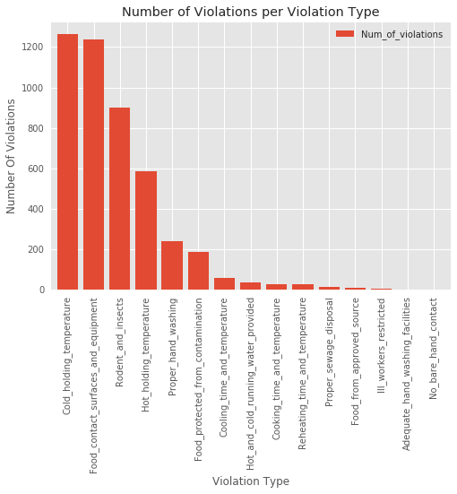

```python
with plt.style.context(('seaborn', 'ggplot')):
    violation_type_to_cnt.plot(kind='bar', width=0.8)
    plt.xlabel('Violation Type')
    plt.ylabel('Number Of Violations')
    plt.title('Number of Violations per Violation Type')
```

### Step 3.2 - Create a line graph that shows the percent of restaurant inspections that have at least one violation by month and year. Are inspections getting harder or easier over time? Is there a particular month where more restaurants pass? Write 2-4 sentences with your observations.

```python
percent_violation_per_month = food_inspection[food_inspection.Restaurant == True].groupby(by='Inspection_month').mean()[['Out_of_compliance']] * 100
percent_violation_per_month
```

| Inspection_month | Out_of_compliance |
| --- | --- |
| 1 | 38.715596 |
| 2 | 40.595903 |
| 3 | 44.422701 |
| 4 | 36.036036 |
| 5 | 47.600000 |
| 6 | 45.693431 |
| 7 | 46.734398 |
| 8 | 44.172662 |
| 9 | 43.295019 |
| 10 | 42.463235 |
| 11 | 43.736264 |
| 12 | 39.457203 |

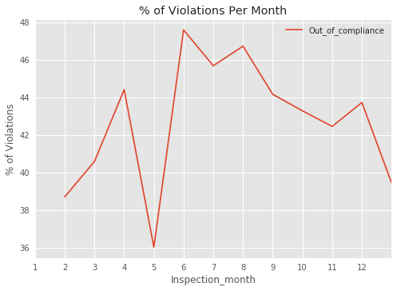

```python
with plt.style.context(('seaborn', 'ggplot')):
    percent_violation_per_month.plot()
    plt.ylabel('% of Violations')
    plt.xticks(range(12), range(1,13))
    plt.title('% of Violations Per Month')
```

```python
percent_violation_per_year = food_inspection[food_inspection.Restaurant == True].groupby(by='Inspection_year').mean()[['Out_of_compliance']] * 100
percent_violation_per_year
```

| Inspection_year | Out_of_compliance |
| --- | --- |
| 2011 | 28.260870 |
| 2012 | 22.832370 |
| 2013 | 21.818182 |
| 2014 | 39.135654 |
| 2015 | 45.068929 |
| 2016 | 47.962382 |
| 2017 | 48.046875 |
| 2018 | 46.687371 |
| 2019 | 46.766169 |

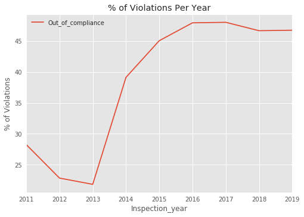

```python
with plt.style.context(('seaborn', 'ggplot')):
    percent_violation_per_year.plot()
    plt.ylabel('% of Violations')
    mini, maxi = int(percent_violation_per_year.index[0]), int(percent_violation_per_year.index[-1])+1
    plt.title('% of Violations Per Year')
```

**Findings:** From above graph, we can see that restaurants violations went down till 2013 and then it started peaking again till 2019. It seems from this graph that its becoming hard to control violations.

### Step 3.3 - Create a map that shows all of the restaurants. Color the restaurants with at least one violation in red. Are there particular areas with more violations? If there are clusters of violations, either through interactive visualization or by manually inspecting the data, look at the types of violations where there are clusters. Are there any trends? Write 2-4 sentences with your observations. If you did not use interactive visualization, explain how you explored trends in violation type by area. You may also create a second map showing violation types.

```python
out_of_compliance_count_per_rest = food_inspection[food_inspection.Restaurant == True].groupby(by='Establishment_id').sum()[['Out_of_compliance']].rename(columns={'Out_of_compliance': 'Out_of_compliance_Cnt'})
food_inspection_locations = food_inspection.drop_duplicates(subset=['Establishment_id']).set_index('Establishment_id')[['Location']]
non_compliance_count_per_rest_with_loc = out_of_compliance_count_per_rest.join(food_inspection_locations, how='left')[['Out_of_compliance_Cnt', 'Location']]
non_compliance_count_per_rest_with_loc = non_compliance_count_per_rest_with_loc.dropna()
non_compliance_count_per_rest_with_loc
```

| Establishment_id | Out_of_compliance_Cnt | Location |
| --- | --- | --- |
| 4 | 1 | POINT (-76.96319 38.956102) |
| 8 | 5 | POINT (-77.009748 38.669918) |
| 18 | 7 | POINT (-76.92678 38.793548) |
| 22 | 13 | POINT (-76.886014 38.926632) |
| 35 | 8 | POINT (-76.88486 38.914974) |
| ... | ... | ... |
| 14966 | 1 | POINT (-76.937981 38.98063) |
| 15234 | 1 | POINT (-76.847394 38.922989) |
| 15282 | 1 | POINT (-76.882571 38.769469) |
| 15701 | 0 | POINT (-76.751282 38.816495) |
| 15888 | 0 | POINT (-76.918084 39.027477) |

518 rows × 2 columns

```python
print(Counter(non_compliance_count_per_rest_with_loc.Out_of_compliance_Cnt))
```

```
Counter({6: 67, 5: 65, 7: 58, 4: 57, 3: 56, 1: 47, 8: 42, 2: 35, 10: 25, 9: 18, 0: 14, 11: 12, 12: 7, 13: 5, 14: 4, 15: 2, 16: 1, 18: 1, 19: 1, 21: 1})
```

```python
locations = np.array([loc.replace('(','').replace(')','').split(' ')[1:] for loc in non_compliance_count_per_rest_with_loc.Location]).astype(np.float32)
locations[:10]
```

```
array([[-76.96319 ,  38.9561  ],
       [-77.00975 ,  38.669918],
       [-76.92678 ,  38.79355 ],
       [-76.88602 ,  38.926632],
       [-76.88486 ,  38.914974],
       [-76.852715,  38.990913],
       [-76.8435  ,  38.965008],
       [-76.837715,  38.90145 ],
       [-76.928406,  38.792397],
       [-76.913086,  38.852474]], dtype=float32)
```

```python
lng, lat = locations[:,0], locations[:,1]
non_compliance_count_per_rest_with_loc['lat'] = lat
non_compliance_count_per_rest_with_loc['lng'] = lng
non_compliance_count_per_rest_with_loc.head()
```

| Establishment_id | Out_of_compliance_Cnt | Location | lat | lng |
| --- | --- | --- | --- | --- |
| 4 | 1 | POINT (-76.96319 38.956102) | 38.956100 | -76.963188 |
| 8 | 5 | POINT (-77.009748 38.669918) | 38.669918 | -77.009750 |
| 18 | 7 | POINT (-76.92678 38.793548) | 38.793549 | -76.926781 |
| 22 | 13 | POINT (-76.886014 38.926632) | 38.926632 | -76.886017 |
| 35 | 8 | POINT (-76.88486 38.914974) | 38.914974 | -76.884857 |

```python
mid_lat = (non_compliance_count_per_rest_with_loc.lat.min() + non_compliance_count_per_rest_with_loc.lat.max())/2
mid_lng = (non_compliance_count_per_rest_with_loc.lng.min() + non_compliance_count_per_rest_with_loc.lng.max())/2

folium_map = folium.Map(location=(mid_lat, mid_lng),
                        zoom_start=12,
                        tiles="CartoDB dark_matter")

for e_id in non_compliance_count_per_rest_with_loc.index:
    folium.CircleMarker(location=(non_compliance_count_per_rest_with_loc.loc[e_id]['lat'], non_compliance_count_per_rest_with_loc.loc[e_id]['lng']),
                            radius=float(non_compliance_count_per_rest_with_loc.loc[e_id]['Out_of_compliance_Cnt']+1),
                            color='red' if non_compliance_count_per_rest_with_loc.loc[e_id]['Out_of_compliance_Cnt'] > 0 else 'white',
                            popup=str(e_id) + ':' + str(non_compliance_count_per_rest_with_loc.loc[e_id]['Out_of_compliance_Cnt']),
                            tooltip=str(e_id) + ', Violations : ' + str(non_compliance_count_per_rest_with_loc.loc[e_id]['Out_of_compliance_Cnt']),
                            fill=True).add_to(folium_map)

folium_map.save('loc_wise_map.html')
```

```python
mid_lat = (non_compliance_count_per_rest_with_loc.lat.min() + non_compliance_count_per_rest_with_loc.lat.max())/2
mid_lng = (non_compliance_count_per_rest_with_loc.lng.min() + non_compliance_count_per_rest_with_loc.lng.max())/2


fig = go.Figure()

for e_id in non_compliance_count_per_rest_with_loc.index:
    cnt = non_compliance_count_per_rest_with_loc.loc[e_id]['Out_of_compliance_Cnt']
    fig.add_trace(go.Scattermapbox(
        lat= [non_compliance_count_per_rest_with_loc.loc[e_id].lat],
        lon=[non_compliance_count_per_rest_with_loc.loc[e_id].lng],
        mode='markers',
        marker=go.scattermapbox.Marker(
            size= 8 if cnt == 0 else 12,
            color = 'white' if cnt==0 else 'red',
            opacity=0.7
        ),
        text=[str(e_id) + ', Violations : ' + str(non_compliance_count_per_rest_with_loc.loc[e_id]['Out_of_compliance_Cnt'])],

    ))

fig.update_layout(
    title='Violation Count distribution',
    autosize=True,
    hovermode='closest',
    showlegend=False,
    mapbox=go.layout.Mapbox(
        accesstoken=mapbox_access_token,
        bearing=0,
        center=go.layout.mapbox.Center(
            lat=mid_lat,
            lon=mid_lng
        ),
        pitch=0,
        zoom=9,
        style = 'dark'
    ),
)

fig.show()
```

[interactive chart not shown]

```python
food_inspection[food_inspection.Restaurant == True].groupby('City').sum()[compliance_type_columns].sort_values(compliance_type_columns, ascending=False)
```

| City | Food_from_approved_source | Food_protected_from_contamination | Ill_workers_restricted | Proper_hand_washing | Cooling_time_and_temperature | Cold_holding_temperature | Hot_holding_temperature | Cooking_time_and_temperature | Reheating_time_and_temperature | Hot_and_cold_running_water_provided | Proper_sewage_disposal | No_bare_hand_contact | Adequate_hand_washing_facilities | Rodent_and_insects | Food_contact_surfaces_and_equipment |
| --- | --- | --- | --- | --- | --- | --- | --- | --- | --- | --- | --- | --- | --- | --- | --- |
| CLINTON | 3 | 11 | 1 | 44 | 8 | 126 | 74 | 1 | 3 | 3 | 5 | 0 | 0 | 68 | 52 |
| UPPER MARLBORO | 1 | 16 | 0 | 14 | 1 | 104 | 42 | 3 | 2 | 3 | 0 | 0 | 0 | 55 | 120 |
| COLLEGE PARK | 1 | 11 | 1 | 11 | 0 | 34 | 23 | 0 | 1 | 0 | 0 | 0 | 0 | 31 | 42 |
| LAUREL | 1 | 11 | 0 | 17 | 6 | 84 | 31 | 4 | 0 | 0 | 2 | 0 | 0 | 31 | 45 |
| Forestville | 1 | 3 | 0 | 2 | 2 | 4 | 4 | 0 | 0 | 0 | 0 | 0 | 0 | 2 | 5 |
| CAMP SPRINGS | 1 | 3 | 0 | 0 | 1 | 11 | 13 | 0 | 0 | 0 | 1 | 0 | 0 | 7 | 8 |
| BOWIE | 0 | 16 | 0 | 10 | 0 | 103 | 25 | 2 | 2 | 3 | 0 | 0 | 0 | 67 | 65 |
| OXON HILL | 0 | 13 | 0 | 9 | 4 | 73 | 28 | 4 | 4 | 4 | 0 | 0 | 0 | 49 | 69 |
| CAPITOL HEIGHTS | 0 | 12 | 0 | 8 | 3 | 71 | 48 | 3 | 2 | 5 | 0 | 0 | 0 | 84 | 131 |
| SUITLAND | 0 | 11 | 1 | 11 | 2 | 50 | 22 | 1 | 2 | 3 | 1 | 0 | 0 | 40 | 54 |
| DISTRICT HTS | 0 | 8 | 0 | 7 | 1 | 39 | 29 | 0 | 0 | 0 | 1 | 0 | 0 | 58 | 60 |
| LANDOVER | 0 | 8 | 0 | 2 | 1 | 46 | 17 | 0 | 0 | 1 | 0 | 0 | 0 | 46 | 80 |
| HYATTSVILLE | 0 | 7 | 0 | 9 | 1 | 44 | 18 | 1 | 1 | 0 | 0 | 0 | 0 | 33 | 29 |
| NATIONAL HARBOR | 0 | 7 | 0 | 2 | 5 | 68 | 22 | 1 | 2 | 0 | 0 | 0 | 0 | 26 | 58 |
| GREENBELT | 0 | 6 | 0 | 17 | 6 | 50 | 30 | 1 | 0 | 1 | 0 | 0 | 0 | 29 | 22 |
| BELTSVILLE | 0 | 6 | 0 | 11 | 4 | 44 | 18 | 1 | 0 | 0 | 1 | 0 | 0 | 14 | 41 |
| FORT WASHINGTON | 0 | 6 | 0 | 1 | 1 | 16 | 6 | 1 | 1 | 2 | 0 | 0 | 0 | 25 | 28 |
| DISTRICT HEIGHTS | 0 | 4 | 0 | 14 | 4 | 31 | 18 | 1 | 3 | 0 | 1 | 0 | 0 | 39 | 50 |
| TEMPLE HILLS | 0 | 4 | 0 | 4 | 0 | 40 | 15 | 1 | 0 | 4 | 1 | 0 | 0 | 28 | 26 |
| BRENTWOOD | 0 | 3 | 0 | 3 | 0 | 8 | 3 | 0 | 0 | 0 | 1 | 0 | 0 | 1 | 13 |
| BRANDYWINE | 0 | 3 | 0 | 1 | 2 | 22 | 8 | 1 | 0 | 0 | 0 | 0 | 0 | 7 | 42 |
| SPRINGDALE | 0 | 2 | 1 | 2 | 0 | 24 | 13 | 1 | 0 | 0 | 0 | 0 | 0 | 22 | 26 |
| MITCHELLVILLE | 0 | 2 | 1 | 1 | 0 | 25 | 6 | 0 | 0 | 2 | 0 | 0 | 0 | 7 | 23 |
| LANHAM-SEABROOK | 0 | 2 | 0 | 10 | 0 | 24 | 11 | 0 | 0 | 1 | 0 | 0 | 0 | 27 | 21 |
| NEW CARROLLTON | 0 | 2 | 0 | 9 | 2 | 24 | 12 | 0 | 0 | 2 | 0 | 0 | 0 | 22 | 26 |
| GLENARDEN | 0 | 2 | 0 | 3 | 0 | 7 | 7 | 1 | 0 | 0 | 0 | 0 | 0 | 4 | 10 |
| LANHAM | 0 | 2 | 0 | 1 | 1 | 5 | 4 | 0 | 1 | 1 | 1 | 0 | 0 | 6 | 9 |
| ACCOKEEK | 0 | 1 | 0 | 7 | 1 | 15 | 10 | 0 | 0 | 1 | 0 | 0 | 0 | 9 | 15 |
| RIVERDALE | 0 | 1 | 0 | 2 | 0 | 13 | 3 | 0 | 1 | 1 | 0 | 0 | 0 | 9 | 7 |
| TAKOMA PARK | 0 | 1 | 0 | 1 | 0 | 9 | 3 | 0 | 0 | 1 | 1 | 0 | 0 | 2 | 3 |
| NATIONAL HABOR | 0 | 1 | 0 | 1 | 0 | 1 | 0 | 0 | 0 | 0 | 0 | 0 | 0 | 3 | 4 |
| CHILLUM | 0 | 1 | 0 | 0 | 0 | 5 | 3 | 0 | 0 | 0 | 0 | 0 | 0 | 1 | 3 |
| LARGO | 0 | 0 | 0 | 3 | 1 | 13 | 8 | 0 | 0 | 0 | 0 | 0 | 0 | 15 | 26 |
| WEST HYATTSVILLE | 0 | 0 | 0 | 2 | 0 | 11 | 3 | 0 | 0 | 0 | 0 | 0 | 0 | 10 | 6 |
| MOUNT RAINIER | 0 | 0 | 0 | 1 | 0 | 1 | 1 | 0 | 0 | 0 | 0 | 0 | 0 | 1 | 0 |
| CHEVERLY | 0 | 0 | 0 | 0 | 0 | 5 | 5 | 1 | 1 | 0 | 0 | 0 | 0 | 0 | 3 |
| FORESTVILLE | 0 | 0 | 0 | 0 | 0 | 4 | 1 | 0 | 1 | 0 | 0 | 0 | 0 | 1 | 3 |
| Riverdale | 0 | 0 | 0 | 0 | 0 | 3 | 0 | 0 | 0 | 0 | 0 | 0 | 0 | 0 | 0 |
| Camp Springs | 0 | 0 | 0 | 0 | 0 | 2 | 0 | 0 | 0 | 0 | 0 | 0 | 0 | 4 | 2 |
| BLADENSBURG | 0 | 0 | 0 | 0 | 0 | 1 | 0 | 0 | 0 | 0 | 0 | 0 | 0 | 9 | 3 |
| Berwyn Heights | 0 | 0 | 0 | 0 | 0 | 0 | 0 | 0 | 0 | 0 | 0 | 0 | 0 | 4 | 1 |
| District Heights | 0 | 0 | 0 | 0 | 0 | 0 | 0 | 0 | 0 | 0 | 0 | 0 | 0 | 1 | 3 |
| NATIONAL | 0 | 0 | 0 | 0 | 0 | 0 | 0 | 0 | 0 | 0 | 0 | 0 | 0 | 1 | 0 |
| Lanham | 0 | 0 | 0 | 0 | 0 | 0 | 0 | 0 | 0 | 0 | 0 | 0 | 0 | 0 | 1 |
| Capitol Heights | 0 | 0 | 0 | 0 | 0 | 0 | 0 | 0 | 0 | 0 | 0 | 0 | 0 | 0 | 0 |

`Food_from_approved_source`, `Ill_workers_restricted`, `Cooling_time_and_temperature`, `Cooking_time_and_temperature`, `Reheating_time_and_temperature`, `Hot_and_cold_running_water_provided`, `Proper_sewage_disposal`, `No_bare_hand_contact`, `Adequate_hand_washing_facilities` are very least occurring violations.

`Food_protected_from_contamination`, `Proper_hand_washing`, `Cold_holding_temperature`, `Hot_holding_temperature`, `Rodent_and_insects`, `Food_contact_surfaces_and_equipment` are quite commonly occurring violations.

# Exercise #4 - All the photos! Sort of...

This assignment builds off of previous Exercise from weeks ago, scraping data from https://pokemondb.net

### Step 4.1: Start with your deduplicated pokedex data. Just like in Step 2.4 from HW #4, create a new column in the DataFrame called sample2 that tags every 12th pokemon. (This will reduce our sample size.)

```python
soup = BeautifulSoup(requests.get('https://pokemondb.net/pokedex/all').content, 'html.parser')
all_rows = soup.find_all('tr')

def create_data_frame(all_rows):
    header_names = []
    rows_data = []
    for row in all_rows:
        single_row_data = []
        headers = row.find_all('th')
        for header in headers:
            header_names.append(header.text)
            if header.text == 'Name':
                header_names.append('URL')
        row_content = row.find_all('td')
        for val in row_content:
            single_row_data.append(val.text)
            if val.get('class')[0] == 'cell-name':
                hyperlink = val.find('a')
                single_row_data.append(hyperlink['href'])
        if single_row_data:
            rows_data.append(single_row_data)

    return pd.DataFrame(rows_data, columns=header_names)

final_df = create_data_frame(all_rows)

final_df['#'] = final_df['#'].astype('int')
final_df['Total'] = final_df['Total'].astype('int')
final_df['HP'] = final_df['HP'].astype('int')
final_df['Attack'] = final_df['Attack'].astype('int')
final_df['Defense'] = final_df['Defense'].astype('int')
final_df['Sp. Atk'] = final_df['Sp. Atk'].astype('int')
final_df['Sp. Def'] = final_df['Sp. Def'].astype('int')
final_df['Speed'] = final_df['Speed'].astype('int')
final_df['Type'] = final_df['Type'].str.strip()

types = []
for val in final_df.Type:
    types.extend(val.strip().split(' '))
unique_types = list(set(types))

types_data = []
for row in final_df.Type:
    row_type_dummy = [1 if typ in row else 0for typ in unique_types]
    types_data.append(row_type_dummy)

types_data = np.array(types_data)

for i, typ in enumerate(unique_types):
    final_df[typ] = types_data[:, i]

final_df = final_df.drop_duplicates(subset=['URL'])
final_df.head(10)
```

|  | # | Name | URL | Type | Total | HP | Attack | Defense | Sp. Atk | Sp. Def | Speed | Flying | Fairy | Electric | Dragon | Rock | Ghost | Grass | Ice | Normal | Fire | Fighting | Dark | Water | Steel | Psychic | Bug | Poison | Ground |
| --- | --- | --- | --- | --- | --- | --- | --- | --- | --- | --- | --- | --- | --- | --- | --- | --- | --- | --- | --- | --- | --- | --- | --- | --- | --- | --- | --- | --- | --- |
| 0 | 1 | Bulbasaur | /pokedex/bulbasaur | Grass Poison | 318 | 45 | 49 | 49 | 65 | 65 | 45 | 0 | 0 | 0 | 0 | 0 | 0 | 1 | 0 | 0 | 0 | 0 | 0 | 0 | 0 | 0 | 0 | 1 | 0 |
| 1 | 2 | Ivysaur | /pokedex/ivysaur | Grass Poison | 405 | 60 | 62 | 63 | 80 | 80 | 60 | 0 | 0 | 0 | 0 | 0 | 0 | 1 | 0 | 0 | 0 | 0 | 0 | 0 | 0 | 0 | 0 | 1 | 0 |
| 2 | 3 | Venusaur | /pokedex/venusaur | Grass Poison | 525 | 80 | 82 | 83 | 100 | 100 | 80 | 0 | 0 | 0 | 0 | 0 | 0 | 1 | 0 | 0 | 0 | 0 | 0 | 0 | 0 | 0 | 0 | 1 | 0 |
| 4 | 4 | Charmander | /pokedex/charmander | Fire | 309 | 39 | 52 | 43 | 60 | 50 | 65 | 0 | 0 | 0 | 0 | 0 | 0 | 0 | 0 | 0 | 1 | 0 | 0 | 0 | 0 | 0 | 0 | 0 | 0 |
| 5 | 5 | Charmeleon | /pokedex/charmeleon | Fire | 405 | 58 | 64 | 58 | 80 | 65 | 80 | 0 | 0 | 0 | 0 | 0 | 0 | 0 | 0 | 0 | 1 | 0 | 0 | 0 | 0 | 0 | 0 | 0 | 0 |
| 6 | 6 | Charizard | /pokedex/charizard | Fire Flying | 534 | 78 | 84 | 78 | 109 | 85 | 100 | 1 | 0 | 0 | 0 | 0 | 0 | 0 | 0 | 0 | 1 | 0 | 0 | 0 | 0 | 0 | 0 | 0 | 0 |
| 9 | 7 | Squirtle | /pokedex/squirtle | Water | 314 | 44 | 48 | 65 | 50 | 64 | 43 | 0 | 0 | 0 | 0 | 0 | 0 | 0 | 0 | 0 | 0 | 0 | 0 | 1 | 0 | 0 | 0 | 0 | 0 |
| 10 | 8 | Wartortle | /pokedex/wartortle | Water | 405 | 59 | 63 | 80 | 65 | 80 | 58 | 0 | 0 | 0 | 0 | 0 | 0 | 0 | 0 | 0 | 0 | 0 | 0 | 1 | 0 | 0 | 0 | 0 | 0 |
| 11 | 9 | Blastoise | /pokedex/blastoise | Water | 530 | 79 | 83 | 100 | 85 | 105 | 78 | 0 | 0 | 0 | 0 | 0 | 0 | 0 | 0 | 0 | 0 | 0 | 0 | 1 | 0 | 0 | 0 | 0 | 0 |
| 13 | 10 | Caterpie | /pokedex/caterpie | Bug | 195 | 45 | 30 | 35 | 20 | 20 | 45 | 0 | 0 | 0 | 0 | 0 | 0 | 0 | 0 | 0 | 0 | 0 | 0 | 0 | 0 | 0 | 1 | 0 | 0 |

```python
final_df['Sample'] = ['sample' if i%4 == 0 else None for i in final_df['#']]
final_df['Sample2'] = ['sample' if i%12 == 0 else None for i in final_df['#']]
final_df.head(15)
```

|  | # | Name | URL | Type | Total | HP | Attack | Defense | Sp. Atk | Sp. Def | Speed | Flying | Fairy | Electric | Dragon | Rock | Ghost | Grass | Ice | Normal | Fire | Fighting | Dark | Water | Steel | Psychic | Bug | Poison | Ground | … |
| --- | --- | --- | --- | --- | --- | --- | --- | --- | --- | --- | --- | --- | --- | --- | --- | --- | --- | --- | --- | --- | --- | --- | --- | --- | --- | --- | --- | --- | --- | --- |
| 0 | 1 | Bulbasaur | /pokedex/bulbasaur | Grass Poison | 318 | 45 | 49 | 49 | 65 | 65 | 45 | 0 | 0 | 0 | 0 | 0 | 0 | 1 | 0 | 0 | 0 | 0 | 0 | 0 | 0 | 0 | 0 | 1 | 0 | … |
| 1 | 2 | Ivysaur | /pokedex/ivysaur | Grass Poison | 405 | 60 | 62 | 63 | 80 | 80 | 60 | 0 | 0 | 0 | 0 | 0 | 0 | 1 | 0 | 0 | 0 | 0 | 0 | 0 | 0 | 0 | 0 | 1 | 0 | … |
| 2 | 3 | Venusaur | /pokedex/venusaur | Grass Poison | 525 | 80 | 82 | 83 | 100 | 100 | 80 | 0 | 0 | 0 | 0 | 0 | 0 | 1 | 0 | 0 | 0 | 0 | 0 | 0 | 0 | 0 | 0 | 1 | 0 | … |
| 4 | 4 | Charmander | /pokedex/charmander | Fire | 309 | 39 | 52 | 43 | 60 | 50 | 65 | 0 | 0 | 0 | 0 | 0 | 0 | 0 | 0 | 0 | 1 | 0 | 0 | 0 | 0 | 0 | 0 | 0 | 0 | … |
| 5 | 5 | Charmeleon | /pokedex/charmeleon | Fire | 405 | 58 | 64 | 58 | 80 | 65 | 80 | 0 | 0 | 0 | 0 | 0 | 0 | 0 | 0 | 0 | 1 | 0 | 0 | 0 | 0 | 0 | 0 | 0 | 0 | … |
| 6 | 6 | Charizard | /pokedex/charizard | Fire Flying | 534 | 78 | 84 | 78 | 109 | 85 | 100 | 1 | 0 | 0 | 0 | 0 | 0 | 0 | 0 | 0 | 1 | 0 | 0 | 0 | 0 | 0 | 0 | 0 | 0 | … |
| 9 | 7 | Squirtle | /pokedex/squirtle | Water | 314 | 44 | 48 | 65 | 50 | 64 | 43 | 0 | 0 | 0 | 0 | 0 | 0 | 0 | 0 | 0 | 0 | 0 | 0 | 1 | 0 | 0 | 0 | 0 | 0 | … |
| 10 | 8 | Wartortle | /pokedex/wartortle | Water | 405 | 59 | 63 | 80 | 65 | 80 | 58 | 0 | 0 | 0 | 0 | 0 | 0 | 0 | 0 | 0 | 0 | 0 | 0 | 1 | 0 | 0 | 0 | 0 | 0 | … |
| 11 | 9 | Blastoise | /pokedex/blastoise | Water | 530 | 79 | 83 | 100 | 85 | 105 | 78 | 0 | 0 | 0 | 0 | 0 | 0 | 0 | 0 | 0 | 0 | 0 | 0 | 1 | 0 | 0 | 0 | 0 | 0 | … |
| 13 | 10 | Caterpie | /pokedex/caterpie | Bug | 195 | 45 | 30 | 35 | 20 | 20 | 45 | 0 | 0 | 0 | 0 | 0 | 0 | 0 | 0 | 0 | 0 | 0 | 0 | 0 | 0 | 0 | 1 | 0 | 0 | … |
| 14 | 11 | Metapod | /pokedex/metapod | Bug | 205 | 50 | 20 | 55 | 25 | 25 | 30 | 0 | 0 | 0 | 0 | 0 | 0 | 0 | 0 | 0 | 0 | 0 | 0 | 0 | 0 | 0 | 1 | 0 | 0 | … |
| 15 | 12 | Butterfree | /pokedex/butterfree | Bug Flying | 395 | 60 | 45 | 50 | 90 | 80 | 70 | 1 | 0 | 0 | 0 | 0 | 0 | 0 | 0 | 0 | 0 | 0 | 0 | 0 | 0 | 0 | 1 | 0 | 0 | … |
| 16 | 13 | Weedle | /pokedex/weedle | Bug Poison | 195 | 40 | 35 | 30 | 20 | 20 | 50 | 0 | 0 | 0 | 0 | 0 | 0 | 0 | 0 | 0 | 0 | 0 | 0 | 0 | 0 | 0 | 1 | 1 | 0 | … |
| 17 | 14 | Kakuna | /pokedex/kakuna | Bug Poison | 205 | 45 | 25 | 50 | 25 | 25 | 35 | 0 | 0 | 0 | 0 | 0 | 0 | 0 | 0 | 0 | 0 | 0 | 0 | 0 | 0 | 0 | 1 | 1 | 0 | … |
| 18 | 15 | Beedrill | /pokedex/beedrill | Bug Poison | 395 | 65 | 90 | 40 | 45 | 80 | 75 | 0 | 0 | 0 | 0 | 0 | 0 | 0 | 0 | 0 | 0 | 0 | 0 | 0 | 0 | 0 | 1 | 1 | 0 | … |

### Step 4.2: Scrape the photo URLs for each pokemon in sample2 like in Step 3.1 from HW #4.

### Step 4.3: Display the photos for all of the sample2 pokemon in your Jupyter notebook. Example code for how to display multiple images in a loop is below. Display(Image(url=**_**, unconfined=True))

```python
for pokemon_name in final_df[final_df.Sample2 == 'sample'].Name.values:
    soup = BeautifulSoup(requests.get('https://pokemondb.net/pokedex/%s'%pokemon_name).content)
    try:
        image_url = soup.find_all('img')[0]['src']
    except:
        image_url = None
    #image_content = requests.get(image_url).content
    if image_url:
        display(Image(url=image_url, unconfined=True))
```

[figure not shown]

# Exercise #5 - Rescrape and Clean the Location Table

### Step5.1: Using BeautifulSoup, scrape the Location table for Bulbasaur properly and add it to a DataFrame. When multiple columns are combined, separate the columns and duplicate the location information. For example, the column "Red Blue" that contains "Pallet Town" will become two columns-- "Red" with location "Pallet Town" and "Blue" with location "Pallet Town." Transpose the DataFrame so the video game (e.g. "Red") is the column name.

```python
pokemon_name = 'bulbasaur'
url = 'https://pokemondb.net/pokedex/%s'%pokemon_name
tables = pd.read_html(requests.get(url, headers={'User-agent': 'Mozilla/5.0'}).text)
tables[-2]
```

|  | 0 | 1 |
| --- | --- | --- |
| 0 | RedBlue | Pallet Town |
| 1 | Yellow | Cerulean City |
| 2 | GoldSilverCrystal | Trade/migrate from another game |
| 3 | RubySapphire | Trade/migrate from another game |
| 4 | FireRedLeafGreen | Pallet Town |
| 5 | Emerald | Trade/migrate from another game |
| 6 | DiamondPearlPlatinum | Trade/migrate from another game |
| 7 | HeartGoldSoulSilver | Pallet Town |
| 8 | BlackWhiteBlack 2White 2 | Trade/migrate from another game |
| 9 | XY | Lumiose City |
| 10 | Omega RubyAlpha Sapphire | Trade/migrate from another game |
| 11 | SunMoon | Trade/migrate from another game |
| 12 | Ultra SunUltra Moon | Route 2 |
| 13 | Let's Go PikachuLet's Go Eevee | Cerulean City, Viridian Forest |

```python
loc_cols = ['Red','Blue', 'Yellow', 'Gold', 'Silver', 'Crystal', 'Ruby', 'Sapphire', 'Emerald', 'FireRed', 'LeafGreen',\
       'Diamond', 'Pearl', 'Platinum', 'HeartGold', 'SoulSilver','Black', 'White', 'Black 2', 'White 2', 'X','Y',\
       'Omega Ruby', 'Alpha Sapphire', "Let's Go Pikachu", "Let's Go Eevee"]

game_dataframe = pd.DataFrame([tables[-2][1].values], columns=tables[-2][0].values)
game_dataframe
```

|  | RedBlue | Yellow | GoldSilverCrystal | RubySapphire | FireRedLeafGreen | Emerald | DiamondPearlPlatinum | HeartGoldSoulSilver | BlackWhiteBlack 2White 2 | XY | Omega RubyAlpha Sapphire | SunMoon | Ultra SunUltra Moon | Let's Go PikachuLet's Go Eevee |
| --- | --- | --- | --- | --- | --- | --- | --- | --- | --- | --- | --- | --- | --- | --- |
| 0 | Pallet Town | Cerulean City | Trade/migrate from another game | Trade/migrate from another game | Pallet Town | Trade/migrate from another game | Trade/migrate from another game | Pallet Town | Trade/migrate from another game | Lumiose City | Trade/migrate from another game | Trade/migrate from another game | Route 2 | Cerulean City, Viridian Forest |

```python
row_data = []
for col in loc_cols:
    col_data_found = False
    for g_col in game_dataframe.columns:
        if col in g_col:
            row_data.append(game_dataframe[g_col].values[0])
            col_data_found = True
            break
    if not col_data_found:
        row_data.append(None)

game_dataframe_modified = pd.DataFrame([row_data], columns=loc_cols)
game_dataframe_modified
```

|  | Red | Blue | Yellow | Gold | Silver | Crystal | Ruby | Sapphire | Emerald | FireRed | LeafGreen | Diamond | Pearl | Platinum | HeartGold | SoulSilver | Black | White | Black 2 | White 2 | X | Y | Omega Ruby | Alpha Sapphire | Let's Go Pikachu | Let's Go Eevee |
| --- | --- | --- | --- | --- | --- | --- | --- | --- | --- | --- | --- | --- | --- | --- | --- | --- | --- | --- | --- | --- | --- | --- | --- | --- | --- | --- |
| 0 | Pallet Town | Pallet Town | Cerulean City | Trade/migrate from another game | Trade/migrate from another game | Trade/migrate from another game | Trade/migrate from another game | Trade/migrate from another game | Trade/migrate from another game | Pallet Town | Pallet Town | Trade/migrate from another game | Trade/migrate from another game | Trade/migrate from another game | Pallet Town | Pallet Town | Trade/migrate from another game | Trade/migrate from another game | Trade/migrate from another game | Trade/migrate from another game | Lumiose City | Cerulean City | Trade/migrate from another game | Trade/migrate from another game | Cerulean City, Viridian Forest | Cerulean City, Viridian Forest |

### Step 5.2: Generalize Step 5.1 for all pokemon in the original sample (the sample from Step 5.1 from HW #4). Append all the data together. If information is not available for a pokemon in a particular game, the column should contain NaN. Display the entire table.

```python
pokemons, game_dataframes = [], []
for pokemon_name in final_df[final_df.Sample == 'sample'].Name:
    url = 'https://pokemondb.net/pokedex/%s'%pokemon_name
    try:
        tables = pd.read_html(requests.get(url, headers={'User-agent': 'Mozilla/5.0'}, timeout=3).text)
        game_dataframe = pd.DataFrame([tables[-2][1].values], columns=tables[-2][0].values)
        game_dataframe.columns = [col.strip() for col in game_dataframe.columns]
    except:
        continue
    if game_dataframe.shape[0]>0:
        game_dataframes.append(game_dataframe)
        pokemons.append(pokemon_name)

print('Number of game dataframes %d'%len(game_dataframes))
```

```
Number of game dataframes 190
```

```python
total_data = []
for pokemon, df in zip(pokemons, game_dataframes):
    row_data = [pokemon]
    for col in loc_cols:
        col_data_found = False
        for g_col in df.columns:
            if col in g_col:
                row_data.append(df[g_col].values[0])
                col_data_found = True
                break
        if not col_data_found:
            row_data.append(None)
    total_data.append(row_data)

locations_data = pd.DataFrame(total_data, columns = ['Name'] + loc_cols).set_index('Name')
locations_data
```

| Name | Red | Blue | Yellow | Gold | Silver | Crystal | Ruby | Sapphire | Emerald | FireRed | LeafGreen | Diamond | Pearl | Platinum | HeartGold | SoulSilver | Black | White | Black 2 | White 2 | X | Y | Omega Ruby | Alpha Sapphire | Let's Go Pikachu | Let's Go Eevee |
| --- | --- | --- | --- | --- | --- | --- | --- | --- | --- | --- | --- | --- | --- | --- | --- | --- | --- | --- | --- | --- | --- | --- | --- | --- | --- | --- |
| Charmander | Pallet Town | Pallet Town | Route 24 | Trade/migrate from another game | Trade/migrate from another game | Trade/migrate from another game | Trade/migrate from another game | Trade/migrate from another game | Trade/migrate from another game | Pallet Town | Pallet Town | Trade/migrate from another game | Trade/migrate from another game | Trade/migrate from another game | Pallet Town | Pallet Town | Trade/migrate from another game | Trade/migrate from another game | Trade/migrate from another game | Trade/migrate from another game | Lumiose City | Route 24 | Trade/migrate from another game | Trade/migrate from another game | Route 3, 4, 24, Rock Tunnel | Route 3, 4, 24, Rock Tunnel |
| Wartortle | Evolve Squirtle | Evolve Squirtle | Evolve Squirtle | Trade/migrate from another game | Trade/migrate from another game | Trade/migrate from another game | Trade/migrate from another game | Trade/migrate from another game | Trade/migrate from another game | Evolve Squirtle | Evolve Squirtle | Trade/migrate from another game | Trade/migrate from another game | Trade/migrate from another game | Evolve Squirtle | Evolve Squirtle | Trade/migrate from another game | Trade/migrate from another game | Trade/migrate from another game | Trade/migrate from another game | Evolve Squirtle | Evolve Squirtle | Trade/migrate from another game | Trade/migrate from another game | Evolve Squirtle | Evolve Squirtle |
| Butterfree | Evolve Caterpie/Metapod | Evolve Caterpie/Metapod | Evolve Caterpie/Metapod | Route 2, 26, 27, 34, 35, 36, 37, 38, 39, Azale... | National Park | Route 2, 24, 25, Ilex Forest, National Park | Trade/migrate from another game | Trade/migrate from another game | Trade/migrate from another game | Evolve Caterpie/Metapod | Evolve Caterpie/Metapod | Evolve Caterpie/Metapod | Evolve Caterpie/Metapod | Evolve Caterpie/Metapod | Route 2, 47, Ilex Forest, National Park, Virid... | National Park | Trade/migrate from another game | Route 12 | Trade/migrate from another game | Trade/migrate from another game | Evolve Caterpie/Metapod | Evolve Caterpie/Metapod | Trade/migrate from another game | Trade/migrate from another game | Viridian Forest | Evolve Caterpie/Metapod |
| Pidgey | Route 1, 2, 3, 5, 6, 7, 8, 12, 13, 14, 15, 21,... | Route 1, 2, 3, 5, 6, 7, 8, 12, 13, 14, 15, 21,... | Route 1, 2, 5, 6, 7, 8, 11, 12, 13, 21, 24, 25... | Route 1, 2, 5, 6, 25, 29, 30, 31, 35, 36, 37, ... | Route 1, 2, 5, 6, 25, 29, 30, 31, 35, 36, 37, ... | Route 1, 2, 5, 25, 29, 30, 31, 32, 34, 35, 36,... | Trade/migrate from another game | Trade/migrate from another game | Trade/migrate from another game | Route 1, 2, 3, 5, 6, 7, 8, 12, 13, 14, 15, 24,... | Route 1, 2, 3, 5, 6, 7, 8, 12, 13, 14, 15, 24,... | Route 229 | Route 229 | Route 229 | Route 1, 2, 5, 6, 25, 29, 30, 31, 35, 36, 37, ... | Route 1, 2, 5, 6, 25, 29, 30, 31, 35, 36, 37, ... | Trade/migrate from another game | White Forest | Trade/migrate from another game | Trade/migrate from another game | Route 2, 3 | Route 1, 2, 5, 6, 7, 8, 11, 12, 13, 21, 24, 25... | Breed Pidgeotto/Pidgeot | Breed Pidgeotto/Pidgeot | Route 1, 2, 5, 6, 7, 8, 11, 12, 13, 14, 15, 16... | Route 1, 2, 5, 6, 7, 8, 11, 12, 13, 14, 15, 16... |
| Raticate | Route 16, 17, 18, 21 | Route 16, 17, 18, 21 | Route 9, 10, 11, 16, 18, 21, Pokémon Mansion | Route 7, 9, 10, 26, 27, 38, 39, Burned Tower, ... | Route 7, 9, 10, 26, 27, 38, 39, Burned Tower, ... | Route 1, 3, 4, 6, 7, 9, 10, 11, 21, 26, 27, 38... | Trade/migrate from another game | Trade/migrate from another game | Trade/migrate from another game | Route 16, 17, 18, Pokémon Mansion | Route 16, 17, 18, Pokémon Mansion | Route 225, 226 | Route 225, 226 | Route 225, 226 | Route 7, 9, 10, 26, 27, 38, 39, 47, Burned Tow... | Route 7, 9, 10, 26, 27, 38, 39, 47, Burned Tow... | Dreamyard | Dreamyard | Dreamyard, Relic Passage, Strange House | Dreamyard, Relic Passage, Strange House | Trade/migrate from another game | Route 9, 10, 11, 16, 18, 21, Pokémon Mansion | Route 118 | Route 118 | Route 7, 8, 9, 10, 11, 16, 17, 18, 21, Pokémon... | Route 7, 8, 9, 10, 11, 16, 17, 18, 21, Pokémon... |
| ... | ... | ... | ... | ... | ... | ... | ... | ... | ... | ... | ... | ... | ... | ... | ... | ... | ... | ... | ... | ... | ... | ... | ... | ... | ... | ... |
| Kommo-o | None | None | None | None | None | None | None | None | None | None | None | None | None | None | None | None | None | None | None | None | None | None | None | None | Location data not yet available | Location data not yet available |
| Lunala | None | None | None | None | None | None | None | None | None | None | None | None | None | None | None | None | None | None | None | None | None | None | None | None | Location data not yet available | Location data not yet available |
| Xurkitree | None | None | None | None | None | None | None | None | None | None | None | None | None | None | None | None | None | None | None | None | None | None | None | None | Location data not yet available | Location data not yet available |
| Necrozma | None | None | None | None | None | None | None | None | None | None | None | None | None | None | None | None | None | None | None | None | None | None | None | None | Location data not yet available | Location data not yet available |
| Naganadel | None | None | None | None | None | None | None | None | None | None | None | None | None | None | None | None | None | None | None | None | None | None | None | None | Location data not yet available | Location data not yet available |

190 rows × 26 columns

# Exercise #6 - Location Analysis Done Right

### Step 6.1: Join the pokedex data to the location DataFrame created in Step 5.2 above. (Exclude pokemon that are not in the sample.) For the locations in pokemon game X, calculate the average total points for each location. Which location has the highest average total point score?

```python
final_df_sample = final_df[final_df['Sample'] == 'sample'].set_index('Name')
print('Sample Dataset Size : ',final_df_sample.shape)
final_df_with_loc_data = final_df_sample.join(locations_data, how='left')
final_df_with_loc_data
```

```
Sample Dataset Size :  (202, 30)
```

| Name | # | URL | Type | Total | HP | Attack | Defense | Sp. Atk | Sp. Def | Speed | Flying | Fairy | Electric | Dragon | Rock | Ghost | Grass | Ice | Normal | Fire | Fighting | Dark | Water | Steel | Psychic | Bug | Poison | Ground | Sample | … |
| --- | --- | --- | --- | --- | --- | --- | --- | --- | --- | --- | --- | --- | --- | --- | --- | --- | --- | --- | --- | --- | --- | --- | --- | --- | --- | --- | --- | --- | --- | --- |
| Charmander | 4 | /pokedex/charmander | Fire | 309 | 39 | 52 | 43 | 60 | 50 | 65 | 0 | 0 | 0 | 0 | 0 | 0 | 0 | 0 | 0 | 1 | 0 | 0 | 0 | 0 | 0 | 0 | 0 | 0 | sample | … |
| Wartortle | 8 | /pokedex/wartortle | Water | 405 | 59 | 63 | 80 | 65 | 80 | 58 | 0 | 0 | 0 | 0 | 0 | 0 | 0 | 0 | 0 | 0 | 0 | 0 | 1 | 0 | 0 | 0 | 0 | 0 | sample | … |
| Butterfree | 12 | /pokedex/butterfree | Bug Flying | 395 | 60 | 45 | 50 | 90 | 80 | 70 | 1 | 0 | 0 | 0 | 0 | 0 | 0 | 0 | 0 | 0 | 0 | 0 | 0 | 0 | 0 | 1 | 0 | 0 | sample | … |
| Pidgey | 16 | /pokedex/pidgey | Normal Flying | 251 | 40 | 45 | 40 | 35 | 35 | 56 | 1 | 0 | 0 | 0 | 0 | 0 | 0 | 0 | 1 | 0 | 0 | 0 | 0 | 0 | 0 | 0 | 0 | 0 | sample | … |
| Raticate | 20 | /pokedex/raticate | Normal | 413 | 55 | 81 | 60 | 50 | 70 | 97 | 0 | 0 | 0 | 0 | 0 | 0 | 0 | 0 | 1 | 0 | 0 | 0 | 0 | 0 | 0 | 0 | 0 | 0 | sample | … |
| ... | ... | ... | ... | ... | ... | ... | ... | ... | ... | ... | ... | ... | ... | ... | ... | ... | ... | ... | ... | ... | ... | ... | ... | ... | ... | ... | ... | ... | ... | … |
| Lunala | 792 | /pokedex/lunala | Psychic Ghost | 680 | 137 | 113 | 89 | 137 | 107 | 97 | 0 | 0 | 0 | 0 | 0 | 1 | 0 | 0 | 0 | 0 | 0 | 0 | 0 | 0 | 1 | 0 | 0 | 0 | sample | … |
| Xurkitree | 796 | /pokedex/xurkitree | Electric | 570 | 83 | 89 | 71 | 173 | 71 | 83 | 0 | 0 | 1 | 0 | 0 | 0 | 0 | 0 | 0 | 0 | 0 | 0 | 0 | 0 | 0 | 0 | 0 | 0 | sample | … |
| Necrozma | 800 | /pokedex/necrozma | Psychic | 600 | 97 | 107 | 101 | 127 | 89 | 79 | 0 | 0 | 0 | 0 | 0 | 0 | 0 | 0 | 0 | 0 | 0 | 0 | 0 | 0 | 1 | 0 | 0 | 0 | sample | … |
| Naganadel | 804 | /pokedex/naganadel | Poison Dragon | 540 | 73 | 73 | 73 | 127 | 73 | 121 | 0 | 0 | 0 | 1 | 0 | 0 | 0 | 0 | 0 | 0 | 0 | 0 | 0 | 0 | 0 | 0 | 1 | 0 | sample | … |
| Meltan | 808 | /pokedex/meltan | Steel | 300 | 46 | 65 | 65 | 55 | 35 | 34 | 0 | 0 | 0 | 0 | 0 | 0 | 0 | 0 | 0 | 0 | 0 | 0 | 0 | 1 | 0 | 0 | 0 | 0 | sample | … |

202 rows × 56 columns

```python
avg_total_point_per_location = final_df_with_loc_data.groupby(by='X').mean()[['Total']]
avg_total_point_per_location.head()
```

| X | Total |
| --- | --- |
| Ambrette Town | 355.5 |
| Breed Electrode | 330.0 |
| Breed Gurdurr/Conkeldurr | 305.0 |
| Breed Hariyama | 237.0 |
| Breed Haunter/Gengar | 310.0 |

```python
avg_total_point_per_location.sort_values(by='Total', ascending=False).head()
```

| X | Total |
| --- | --- |
| Team Flare HQ | 680.0 |
| Sea Spirit's Den, Roaming Kalos | 580.0 |
| Evolve Axew/Fraxure | 540.0 |
| Evolve Rhyhorn/Rhydon | 535.0 |
| Evolve Vanillite/Vanillish | 535.0 |

Location **"Team Flare HQ"** has highest total as we can see above from sorted values.